# Practical Machine Learning Week 4 Assignment

KGS Koh

Saturday, February 25, 2017

This project aims to predict the manner in which participants perform barbell lifts. There were six participants and each were asked to perform unilateral dumbbell biceps curls in five different ways: according to specification (A), throwing the elbows to the front (B), lifting the dumbbell only halfway (C), lowering the dumbbell only halfway (D), and throwing the hips to the front (E). Data is obtained from accelerometers worn on the belt, arm, dumbbell and forearm of the participants. Using this data, we try to select a model that can predict the class of execution of the bicep curls. The data for this project comes from: http://groupware.les.inf.puc-rio.br/har. Reference is also made to the paper, “Qualitative Activity Recognition of Weight Lifting Exercises”, by Velloso, E; Bulling, A; Gellersen, H; Ugulino, W and Fuks, H.

First, we load the required packages and look at the data:

```r
library(dplyr)
library(caret)
data <- read.csv("pml-training.csv")
dim(data)
```

```
## [1] 19622   160
```

```r
head(data)
```

```
##   X user_name raw_timestamp_part_1 raw_timestamp_part_2   cvtd_timestamp
## 1 1  carlitos           1323084231               788290 05/12/2011 11:23
## 2 2  carlitos           1323084231               808298 05/12/2011 11:23
## 3 3  carlitos           1323084231               820366 05/12/2011 11:23
## 4 4  carlitos           1323084232               120339 05/12/2011 11:23
## 5 5  carlitos           1323084232               196328 05/12/2011 11:23
## 6 6  carlitos           1323084232               304277 05/12/2011 11:23
##   new_window num_window roll_belt pitch_belt yaw_belt total_accel_belt
## 1         no         11      1.41       8.07    -94.4                3
## 2         no         11      1.41       8.07    -94.4                3
## 3         no         11      1.42       8.07    -94.4                3
## 4         no         12      1.48       8.05    -94.4                3
## 5         no         12      1.48       8.07    -94.4                3
## 6         no         12      1.45       8.06    -94.4                3
##   kurtosis_roll_belt kurtosis_picth_belt kurtosis_yaw_belt
```

[output cut: 265 more lines]

We see that for each of the four accelerometer sensors, there is raw data of the 9 degrees of freedom Razor inertial measurement units (IMU), as mentioned in the paper quoted, which provide three-axes acceleration(eg. accel_forearm_x, accel_forearm_y, accel_forearm_z), gyroscope and magnetometer data, as well as the Euler angles (roll, pitch and yaw) and total acceleration. In addition there are eight derived features for each Euler angle of each sensor: mean, variance, standard deviation, max, min, amplitude, kurtosis and skewness.

The data further shows a pattern of mostly NA for the eight derived features, except when ‘new_window’ column is ‘yes’. This corresponds to the sliding window approach mentioned in the paper, hence the derived features are calculated over a window. The paper mentioned use of sliding windows varying from 0.5 seconds to 2.5 seconds. This suggests that we can compute our own derived features data using a window we select.

```r
datayes <- data %>% filter(new_window=="yes")
head(datayes[,1:30])
```

```
##     X user_name raw_timestamp_part_1 raw_timestamp_part_2   cvtd_timestamp
## 1  24  carlitos           1323084232               996313 05/12/2011 11:23
## 2  52  carlitos           1323084233               948290 05/12/2011 11:23
## 3  76  carlitos           1323084234               984276 05/12/2011 11:23
## 4 165  carlitos           1323084238               972281 05/12/2011 11:23
## 5 210     pedro           1323094970               968279 05/12/2011 14:22
## 6 241     pedro           1323094971               980388 05/12/2011 14:22
##   new_window num_window roll_belt pitch_belt yaw_belt total_accel_belt
## 1        yes         12      1.51       8.10   -94.40                3
## 2        yes         13      1.27       7.56   -94.10                3
## 3        yes         14      1.18       7.26   -94.10                3
## 4        yes         18      1.01       7.38   -93.80                4
## 5        yes         47    129.00      27.90     2.35               21
## 6        yes         48    128.00      27.80     1.52               21
##   kurtosis_roll_belt kurtosis_picth_belt kurtosis_yaw_belt
```

[output cut: 34 more lines]

Plot of Window Number, coloured by Class:

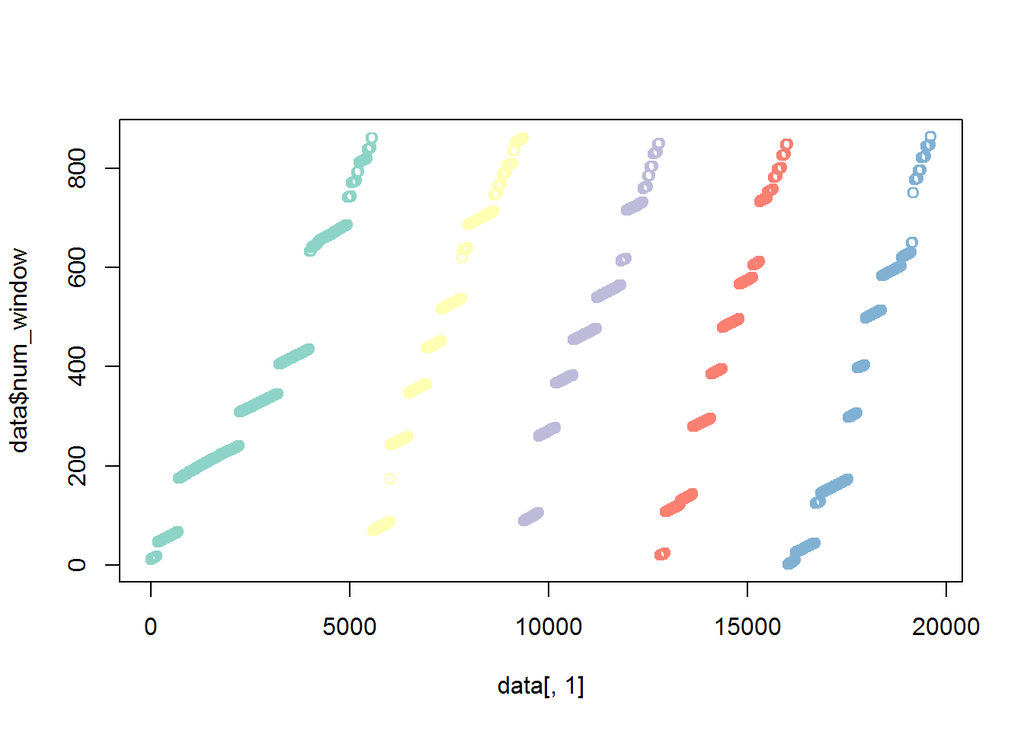

We can thus group by Class and Window Number, thus giving discrete window length of 1 second, which is the simplest grouping.

For the eight features, we leave out amplitude since this is a linear combination of maximum and minimum. Deriving the features to come up with a derived data table:

1. Belt

```r
library(moments)
belt1 <- list(~mean(roll_belt), ~mean(pitch_belt), ~mean(yaw_belt))
belt2 <- list(~sd(roll_belt), ~sd(pitch_belt), ~sd(yaw_belt))
belt3 <- list(~var(roll_belt), ~var(pitch_belt), ~var(yaw_belt))
belt4 <- list(~min(roll_belt), ~min(pitch_belt), ~min(yaw_belt))
belt5 <- list(~max(roll_belt), ~max(pitch_belt), ~max(yaw_belt))
belt6 <- list(~skewness(roll_belt), ~skewness(pitch_belt), ~skewness(yaw_belt))
belt7 <- list(~kurtosis(roll_belt), ~kurtosis(pitch_belt), ~kurtosis(yaw_belt))
beltall <- c(belt1, belt2, belt3, belt4, belt5, belt6, belt7)
```

Do likewise for:

2. Arm
3. Dumbbell
4. Forearm

Finally, the raw features are copied:

```r
othersbelt <- list(~mean(total_accel_belt), ~var(total_accel_belt), ~mean(gyros_belt_x), ~mean(gyros_belt_y), ~mean(gyros_belt_z), ~mean(accel_belt_x), ~mean(accel_belt_y), ~mean(accel_belt_z), ~mean(magnet_belt_x), ~mean(magnet_belt_y), ~mean(magnet_belt_z))
othersarm <- list(~mean(total_accel_arm), ~var(total_accel_arm), ~mean(gyros_arm_x), ~mean(gyros_arm_y), ~mean(gyros_arm_z), ~mean(accel_arm_x), ~mean(accel_arm_y), ~mean(accel_arm_z), ~mean(magnet_arm_x), ~mean(magnet_arm_y), ~mean(magnet_arm_z))
othersdumbbell <- list(~mean(total_accel_dumbbell), ~var(total_accel_dumbbell), ~mean(gyros_dumbbell_x), ~mean(gyros_dumbbell_y), ~mean(gyros_dumbbell_z), ~mean(accel_dumbbell_x), ~mean(accel_dumbbell_y), ~mean(accel_dumbbell_z), ~mean(magnet_dumbbell_x), ~mean(magnet_dumbbell_y), ~mean(magnet_dumbbell_z))
othersforearm <- list(~mean(total_accel_forearm), ~var(total_accel_forearm), ~mean(gyros_forearm_x), ~mean(gyros_forearm_y), ~mean(gyros_forearm_z), ~mean(accel_forearm_x), ~mean(accel_forearm_y), ~mean(accel_forearm_z), ~mean(magnet_forearm_x), ~mean(magnet_forearm_y), ~mean(magnet_forearm_z))
```

The derived data table:

```r
data1 <- data %>% group_by(classe, num_window) %>% summarise_(.dots = c(beltall, othersbelt, armall, othersarm, dumbbellall, othersdumbbell, forearmall, othersforearm)) %>% select(-2)
dim(data1)
```

```
## [1] 858 129
```

From this data table, we separate the rows into a train set and test set:

```r
set.seed(1234)
inTrain <- createDataPartition(data1$classe, p=0.7, list=FALSE)
trainfit <- data1[inTrain,]
testfit <- data1[-inTrain,]
```

```r
modfit <- train(classe ~., data=data1, method= "rf", trControl= trainControl(method="cv"), na.action=na.exclude)
testfitcomplete <- testfit[complete.cases(testfit[,2:129]),]
predtestfit <- predict(modfit, testfit)
confusionMatrix(testfitcomplete$classe, predtestfit)
```

```
## Confusion Matrix and Statistics
##
##           Reference
## Prediction  A  B  C  D  E
##          A 37  0  0  0  0
##          B  0 30  0  0  0
##          C  0  0 28  0  0
##          D  0  0  0 24  0
##          E  0  0  0  0 31
##
## Overall Statistics
##
##                Accuracy : 1
##                  95% CI : (0.9757, 1)
##     No Information Rate : 0.2467
##     P-Value [Acc > NIR] : < 2.2e-16
##
##                   Kappa : 1
##  Mcnemar's Test P-Value : NA
##
## Statistics by Class:
##
##                      Class: A Class: B Class: C Class: D Class: E
## Sensitivity            1.0000      1.0   1.0000     1.00   1.0000
## Specificity            1.0000      1.0   1.0000     1.00   1.0000
## Pos Pred Value         1.0000      1.0   1.0000     1.00   1.0000
## Neg Pred Value         1.0000      1.0   1.0000     1.00   1.0000
## Prevalence             0.2467      0.2   0.1867     0.16   0.2067
## Detection Rate         0.2467      0.2   0.1867     0.16   0.2067
## Detection Prevalence   0.2467      0.2   0.1867     0.16   0.2067
## Balanced Accuracy      1.0000      1.0   1.0000     1.00   1.0000
```

Next, we look at the supplied ‘pml-testing.csv’ data to see if the model fits the new data.

```r
testcases <- read.csv("pml-testing.csv")
fun2 <- function(x) {sum(is.na(x))/length(x) < 0.1}
naremove <- apply(testcases,2,fun2)
testcases <- testcases[,naremove]
dim(testcases)
```

```
## [1] 20 60
```

```r
names(testcases)
```

```
##  [1] "X"                    "user_name"            "raw_timestamp_part_1"
##  [4] "raw_timestamp_part_2" "cvtd_timestamp"       "new_window"
##  [7] "num_window"           "roll_belt"            "pitch_belt"
## [10] "yaw_belt"             "total_accel_belt"     "gyros_belt_x"
## [13] "gyros_belt_y"         "gyros_belt_z"         "accel_belt_x"
## [16] "accel_belt_y"         "accel_belt_z"         "magnet_belt_x"
## [19] "magnet_belt_y"        "magnet_belt_z"        "roll_arm"
## [22] "pitch_arm"            "yaw_arm"              "total_accel_arm"
## [25] "gyros_arm_x"          "gyros_arm_y"          "gyros_arm_z"
## [28] "accel_arm_x"          "accel_arm_y"          "accel_arm_z"
## [31] "magnet_arm_x"         "magnet_arm_y"         "magnet_arm_z"
## [34] "roll_dumbbell"        "pitch_dumbbell"       "yaw_dumbbell"
## [37] "total_accel_dumbbell" "gyros_dumbbell_x"     "gyros_dumbbell_y"
## [40] "gyros_dumbbell_z"     "accel_dumbbell_x"     "accel_dumbbell_y"
## [43] "accel_dumbbell_z"     "magnet_dumbbell_x"    "magnet_dumbbell_y"
## [46] "magnet_dumbbell_z"    "roll_forearm"         "pitch_forearm"
## [49] "yaw_forearm"          "total_accel_forearm"  "gyros_forearm_x"
## [52] "gyros_forearm_y"      "gyros_forearm_z"      "accel_forearm_x"
## [55] "accel_forearm_y"      "accel_forearm_z"      "magnet_forearm_x"
## [58] "magnet_forearm_y"     "magnet_forearm_z"     "problem_id"
```

Data set recleaned:

```r
dotsnew <- c(belt1, othersbelt[-2], arm1, othersarm[-2], dumbbell1, othersdumbbell[-2], forearm1, othersforearm[-2])
datanew <- data %>% group_by(classe, num_window) %>% summarise_(.dots = dotsnew) %>% select(-2)
dim(datanew)
```

```
## [1] 858  53
```

```r
names(datanew)
```

```
##  [1] "classe"                     "mean(roll_belt)"
##  [3] "mean(pitch_belt)"           "mean(yaw_belt)"
##  [5] "mean(total_accel_belt)"     "mean(gyros_belt_x)"
##  [7] "mean(gyros_belt_y)"         "mean(gyros_belt_z)"
##  [9] "mean(accel_belt_x)"         "mean(accel_belt_y)"
## [11] "mean(accel_belt_z)"         "mean(magnet_belt_x)"
## [13] "mean(magnet_belt_y)"        "mean(magnet_belt_z)"
## [15] "mean(roll_arm)"             "mean(pitch_arm)"
## [17] "mean(yaw_arm)"              "mean(total_accel_arm)"
## [19] "mean(gyros_arm_x)"          "mean(gyros_arm_y)"
## [21] "mean(gyros_arm_z)"          "mean(accel_arm_x)"
## [23] "mean(accel_arm_y)"          "mean(accel_arm_z)"
## [25] "mean(magnet_arm_x)"         "mean(magnet_arm_y)"
## [27] "mean(magnet_arm_z)"         "mean(roll_dumbbell)"
## [29] "mean(pitch_dumbbell)"       "mean(yaw_dumbbell)"
## [31] "mean(total_accel_dumbbell)" "mean(gyros_dumbbell_x)"
## [33] "mean(gyros_dumbbell_y)"     "mean(gyros_dumbbell_z)"
## [35] "mean(accel_dumbbell_x)"     "mean(accel_dumbbell_y)"
## [37] "mean(accel_dumbbell_z)"     "mean(magnet_dumbbell_x)"
## [39] "mean(magnet_dumbbell_y)"    "mean(magnet_dumbbell_z)"
## [41] "mean(roll_forearm)"         "mean(pitch_forearm)"
## [43] "mean(yaw_forearm)"          "mean(total_accel_forearm)"
## [45] "mean(gyros_forearm_x)"      "mean(gyros_forearm_y)"
## [47] "mean(gyros_forearm_z)"      "mean(accel_forearm_x)"
## [49] "mean(accel_forearm_y)"      "mean(accel_forearm_z)"
## [51] "mean(magnet_forearm_x)"     "mean(magnet_forearm_y)"
## [53] "mean(magnet_forearm_z)"
```

```r
colnames(testcases)[8:59] <- colnames(datanew)[2:53]
```

Refit the random forest model:

```r
set.seed(1234)
inTrain <- createDataPartition(datanew$classe, p=0.7, list=FALSE)
trainfnew <- datanew[inTrain,]
testfnew <- datanew[-inTrain,]

modfitnew <- train(classe ~., data=datanew, method= "rf", trControl= trainControl(method="cv"), na.action=na.exclude)
testfcompnew <- testfnew[complete.cases(testfnew[,2:53]),]
predtestfnew <- predict(modfitnew, testfnew)
confusionMatrix(testfcompnew$classe, predtestfnew)
```

```
## Confusion Matrix and Statistics
##
##           Reference
## Prediction  A  B  C  D  E
##          A 72  0  0  0  0
##          B  0 50  0  0  0
##          C  0  0 45  0  0
##          D  0  0  0 42  0
##          E  0  0  0  0 46
##
## Overall Statistics
##
##                Accuracy : 1
##                  95% CI : (0.9856, 1)
##     No Information Rate : 0.2824
##     P-Value [Acc > NIR] : < 2.2e-16
##
##                   Kappa : 1
##  Mcnemar's Test P-Value : NA
##
## Statistics by Class:
##
##                      Class: A Class: B Class: C Class: D Class: E
## Sensitivity            1.0000   1.0000   1.0000   1.0000   1.0000
## Specificity            1.0000   1.0000   1.0000   1.0000   1.0000
## Pos Pred Value         1.0000   1.0000   1.0000   1.0000   1.0000
## Neg Pred Value         1.0000   1.0000   1.0000   1.0000   1.0000
## Prevalence             0.2824   0.1961   0.1765   0.1647   0.1804
## Detection Rate         0.2824   0.1961   0.1765   0.1647   0.1804
## Detection Prevalence   0.2824   0.1961   0.1765   0.1647   0.1804
## Balanced Accuracy      1.0000   1.0000   1.0000   1.0000   1.0000
```